# Tutorial for the `lmbayes` package

Author

Søren Højsgaard

Published

March 25, 2025

```r
library(lmbayes)
library(broom)
library(cowplot)
library(ggplot2)
library(dplyr)
library(doBy)
library(tidyr)
```

# 1 Introduction

This tutorial demonstrates how to use the `lmbayes` package to perform (empirical) Bayes estimation in a time-series regression setting. We will use the `child_growth` dataset from the `doBy` package, which contains longitudinal height measurements for children. You need a recent version of doBy which is available on github.

# 2 Load Data and Visualize

We start by loading the data and visualizing the growth trajectories

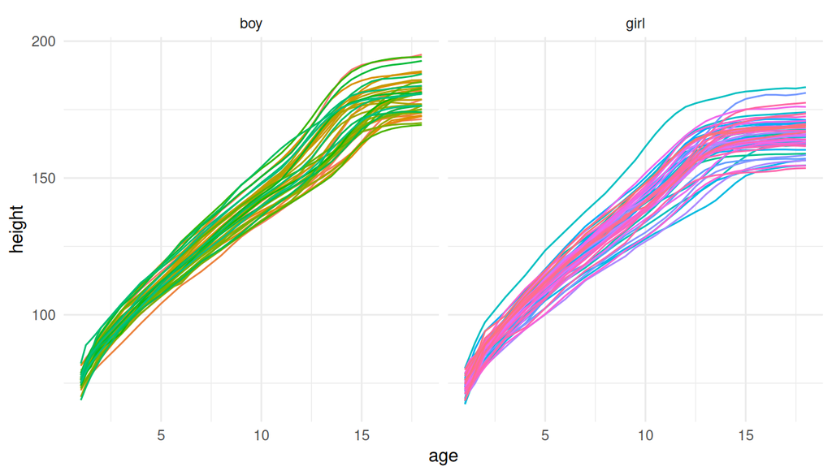

```r
dat <- doBy::child_growth
dat |> ggplot(aes(age,height, group=subject, color=subject)) +
  geom_line() + facet_grid(~gender) + theme_minimal() +
  theme(legend.position = "none")
```

We will focus on the boys for this tutorial.

1. For the first 10 boys we will fit a quadratic model to the height data.
2. We will then use the regression coefficients to estimate a prior distribution for the coefficients.
3. We will then use this prior to combine with the likelihood for another boy for which we only have early data.

# 3 Fit Quadratic Models to Training Data

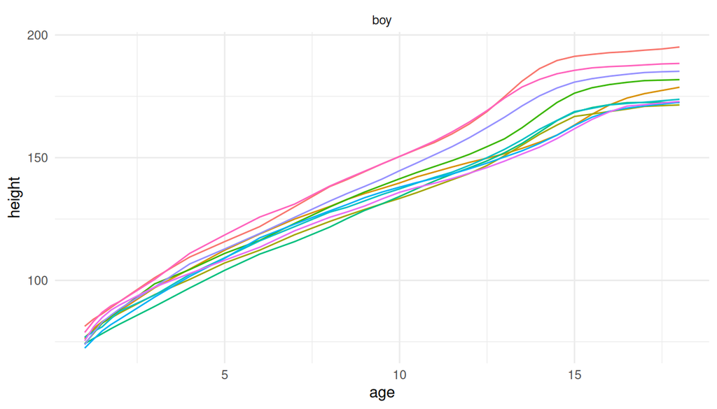

```r
boy.dat  <- dat |> filter(gender=="boy")
sub <- boy.dat$subject |> unique()
train <- boy.dat |> filter(subject %in% sub[1:10])
train |> ggplot(aes(age,height, group=subject, color=subject)) +
  geom_line() + facet_grid(~gender) + theme_minimal() +
  theme(legend.position = "none")
```

```r
fit.list <- train |> lm_by(height ~ age + I(age^2) |subject, data=_)
coef.df <- fit.list |> coef()
coef.df
```

```
      (Intercept)  age I(age^2)
boy01        72.9 9.07  -0.1059
boy02        72.8 7.77  -0.1089
boy03        72.2 6.96  -0.0663
boy04        70.7 8.10  -0.0932
boy05        66.7 7.72  -0.0844
boy06        70.7 7.90  -0.1101
boy07        67.6 8.55  -0.1497
boy08        68.7 9.17  -0.1338
boy09        74.9 6.70  -0.0641
boy10        71.3 9.99  -0.1771
```

```r
sd <- fit.list |> sigma() |> mean()
m  <- colMeans(coef.df)
C  <- cov(coef.df)
pr0 <- list(m=m, C=C, sd=sd)
pr0
```

```
$m
(Intercept)         age    I(age^2)
     70.867       8.193      -0.109

$C
            (Intercept)     age I(age^2)
(Intercept)      6.4825 -0.7858  0.03242
age             -0.7858  1.0359 -0.03229
I(age^2)         0.0324 -0.0323  0.00129

$sd
[1] 2.55
```

## 3.1 There is a new kid in town

If we know data for the first, say 5 years, how well can we predict the height for the next years?

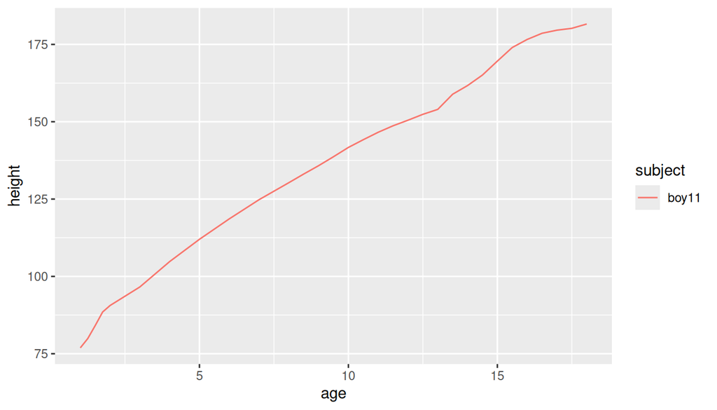

```r
this  <- boy.dat |> filter(subject %in% sub[11])
time.early <- 5
this.early <- this |> filter(age <= time.early)
this |>
    ggplot(aes(age,height, group=subject, color=subject)) + geom_line()
```

## 3.2 Bayesian Linear Regression: Joint and Conditional Distributions

We assume the following model:

- The prior on the regression coefficients is
  $$b \sim \mathcal{N}(m, C)$$
  where $m$ is a $p$-dimensional mean vector and $C$ is a $p \times p$ covariance matrix.
- The observation model is
  $$y \mid b \sim \mathcal{N}(Xb, \sigma^2 I)$$
  where $X$ is an $n \times p$ design matrix, $y$ is an $n$-dimensional response vector, and $\sigma^2$ is the residual variance.

### 3.2.1 Marginal Distribution of $y$

By integrating out $b$, the marginal distribution of $y$ is:
$$y \sim \mathcal{N}(X m, X C X^T + \sigma^2 I)$$

### 3.2.2 Joint Distribution of $(y, b)$

The joint distribution of $y$ and $b$ is multivariate normal:
$$\begin{pmatrix}
b \\\\
y
\end{pmatrix}
\sim \mathcal{N} \left(
\begin{pmatrix}
m \\\\
X m
\end{pmatrix},
\begin{pmatrix}
C & C X^T \\\\
X C & X C X^T + \sigma^2 I
\end{pmatrix}
\right)$$

### 3.2.3 Conditional Distribution of $b \mid y$

From the properties of the multivariate normal, the conditional distribution of $b$ given $y$ is:
$$b \mid y \sim \mathcal{N}(m^*, C^*)$$
where:
$$m^* = m + C X^T (X C X^T + \sigma^2 I)^{-1} (y - X m)$$
$$C^* = C - C X^T (X C X^T + \sigma^2 I)^{-1} X C$$

### 3.2.4 Interpretation via $\Lambda$

Let
$$\Lambda = C X^T (X C X^T + \sigma^2 I)^{-1}$$
so that the posterior mean becomes:
$$m^* = m + \Lambda (y - X m)$$

This form reveals how the prior is updated in the direction of the observed data, scaled by $\Lambda$ — the influence of the data increases as $\sigma^2$ decreases or $C$ becomes less informative.

### 3.2.5 Simplified Forms via Woodbury Identity

The expressions for the posterior mean and covariance can be simplified using the **Woodbury matrix identity**:
$$(A + UCV)^{-1} = A^{-1} - A^{-1} U (C^{-1} + V A^{-1} U)^{-1} V A^{-1}$$
for appropriate matrix dimensions.

In our case, let: $A = \sigma^2 I$, $U = X$, $C = C$ and $V = X^T$. We can then simplify:

#### 3.2.5.1 Posterior Mean Matrix:

$$\Lambda = C X^T (X C X^T + \sigma^2 I)^{-1}$$
can be rewritten as:
$$\Lambda = (C^{-1} + \tfrac{1}{\sigma^2} X^T X)^{-1} \cdot \tfrac{1}{\sigma^2} X^T$$

#### 3.2.5.2 Posterior Covariance:

$$C^* = C - C X^T (X C X^T + \sigma^2 I)^{-1} X C$$
can be rewritten as:
$$C^* = (C^{-1} + \tfrac{1}{\sigma^2} X^T X)^{-1}$$

These are often preferred in implementations, especially when $p$ (number of predictors) is small compared to $n$ (number of observations), since they involve inverting $p \times p$ matrices instead of $n \times n$ matrices.

### 3.2.6 Summary

- The **posterior mean** becomes:
  $$m^* = (C^{-1} + \tfrac{1}{\sigma^2} X^T X)^{-1} \left( C^{-1} m + \tfrac{1}{\sigma^2} X^T y \right)$$
- The **posterior covariance** becomes:
  $$C^* = (C^{-1} + \tfrac{1}{\sigma^2} X^T X)^{-1}$$

This formulation highlights how the posterior combines prior precision ($C^{-1}$) and data precision ($\tfrac{1}{\sigma^2} X^T X$).

### 3.2.7 Optional Convex Combination (Heuristic)

A simple heuristic can be used to approximate the posterior mean as a convex combination of the prior mean and the OLS estimate,

$$m^* \approx \alpha \cdot m + (1 - \alpha) \cdot \hat{b}_{\text{OLS}}$$

where $\hat{b}_{\text{OLS}} = (X^T X)^{-1} X^T y$, and the shrinkage factor $\alpha$ depends on the relative strength of the prior and the data. This expression helps illustrate the idea that Bayesian estimation **shrinks** the data-driven estimate toward the prior mean.

## 3.3 Options in the `lmbayes` package

There are different options with the lmbayes package:

Use the prior from above for fitime.earlying the model to the early data:

```r
lmb1 <- lmb(height ~ age + I(age^2), data=this.early, prior=pr0)
lmb1
```

```
Bayesian linear model object
height ~ age + I(age^2)
[1] 70.621  9.059 -0.136
```

```r
lmb1$prior
```

```
$m
(Intercept)         age    I(age^2)
     70.867       8.193      -0.109

$C
            (Intercept)     age I(age^2)
(Intercept)      6.4825 -0.7858  0.03242
age             -0.7858  1.0359 -0.03229
I(age^2)         0.0324 -0.0323  0.00129

$sd
[1] 2.55
```

```r
lmb1$posterior
```

```
$m
(Intercept)         age    I(age^2)
     70.621       9.059      -0.136

$C
            (Intercept)      age  I(age^2)
(Intercept)      1.2368 -0.44453  0.016320
age             -0.4445  0.21510 -0.008610
I(age^2)         0.0163 -0.00861  0.000599

$sd
[1] 1.79
```

Notice that sd changes from the prior to the posterior although we have not specified a prior for sd. The updated sd is based on the residual sum of squares. Setime.earlying update.sd=FALSE means that sd is not updated.

We can make a cheaper update of $m$ as a convex combination of the prior mean and the OLS estimate of the early data. This is done by setime.earlying alpha to a value between 0 and 1. The update is then

$$\tilde{m} = \alpha \cdot m + (1 - \alpha) \cdot \hat{\beta}_{ols}$$

This gives no posterior variance matrix, but only the “posterior” mean. As such the prior need only the mean m.

```r
lmb2 <- lmb(height ~ age + I(age^2), data=this.early, prior=list(m=m), alpha=0.4)
lmb2
```

```
Bayesian linear model object
height ~ age + I(age^2)
[1] 67.440 11.534 -0.588
```

```r
lmb2$prior
```

```
$m
(Intercept)         age    I(age^2)
     70.867       8.193      -0.109
```

```r
lmb2$posterior
```

```
$m
(Intercept)         age    I(age^2)
     67.440      11.534      -0.588
```

For benchmarking we can fit a model to all the data using ols. We also fit a model to the early data using ols. This can be done using the `lmb` function with no prior specified.

```r
bench <- lmb(height ~ age + I(age^2), data=this)
early <- lmb(height ~ age + I(age^2), data=this.early)
```

We can now compare the predictions from the different models.

```r
this <- this |> add_pred(bench, "bench")
this <- this |> add_pred(early, "early")
this <- this |> add_pred(lmb1, "lmb1")
this <- this |> add_pred(lmb2, "lmb2")
```

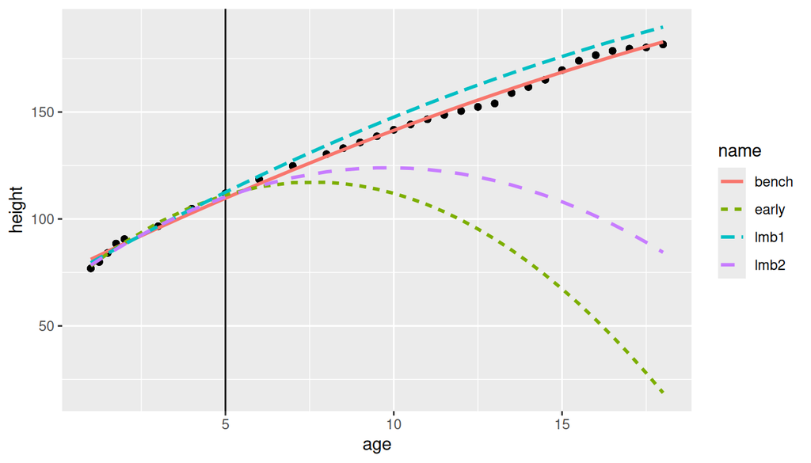

```r
this.long <- this |> pivot_longer(-c(gender, age, subject, height))
this.long |> ggplot(aes(x=age)) +
    geom_vline(xintercept = time.early) +
    geom_point(aes(y=height)) +
    geom_line(aes(y = value, color = name, linetype = name), linewidth = 1)
```

# 4 Insights and Interpretation

- The **prior** is estimated from training children.
- The **Bayesian prediction** (blue) shrinks the early OLS estimate toward the prior.
- The **strength of the prior** ($\alpha$) controls how much the posterior follows the prior.
- When early data is sparse, shrinkage improves stability.